# visualization slides

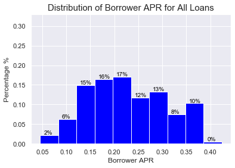

> 74% of all loans have a Borrower APR between 0.1 and 0.3 percent 0.20 to 0.25 is the most concentratd, with 17% It is possible to have a near zero percent APR when a bank is financing loans for third-parties. The best expample of these situations is in the instance of Auto Loans, financed at extremely low rates to incentivize a purchase.

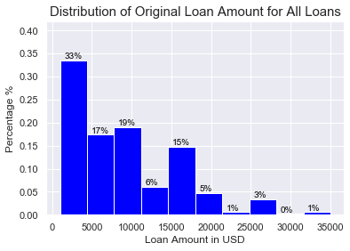

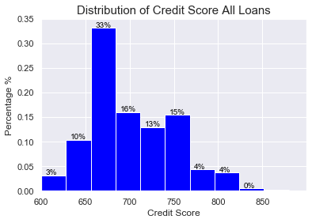

> 59% of the loans had lendees who's Credit Score at the time were between 650 and 725. Only 23% of the the lendees had a Credit Scores of 750 or above.

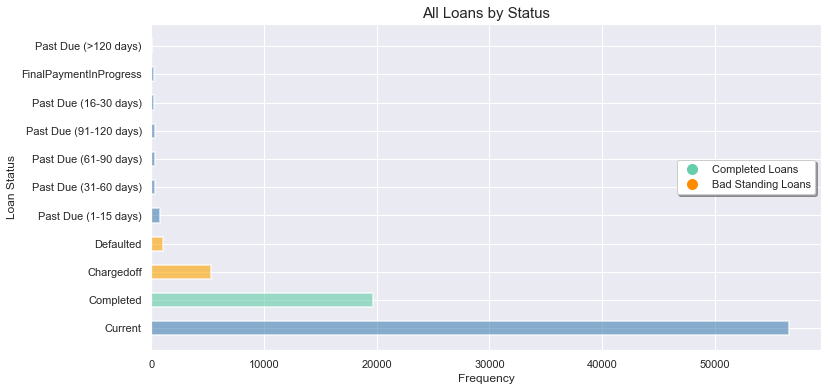

> The Loan Status is categorized by *Current* , *Completed* , *Chargedoff* , *Defaulted* ,*Past Due* by time period, and *Final Payment In Progress* . For the purposes of my analysis, I will key in on the 3 loan statuses of *Defaulted, Chargedoff* , and *Completed*. In my next steps, I will group *Defaulted* loans with *Chargedoff* loans, giving them the label of Bad Standing Loans. These are the loans that have gone that are more than 120 days past due on their payments and outstanding debts deemed uncollectible. I will compare the Bad Standing Loans with the loans that have been *Completed* and distiguish the key features between them.

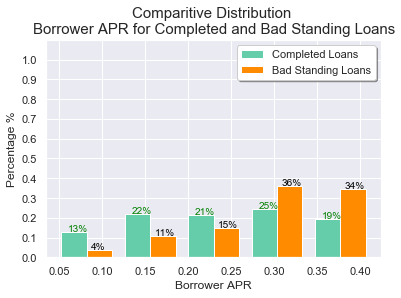

> Once categorized by Completeed Loans and Bad Standing Loans, there are several take aways that can be determined from the comparative distribution of Borrower APR. From Borrower APR of 0 to 0.20, more loans are Completed than those in that end in Default or Chargedoff. As the Borrower APR increases the relationship is switched. 70% of all Bad Standing Loans occurred when the Borrower APR was 0.3 to 0.4. Comparatively only 44% of the Completed loans occurred when the Borrower APR was 0.3 to 0.4. Borrower APR looks to be a key contributor to the liklihood of a loan never being paid off and finishing in Bad Standing

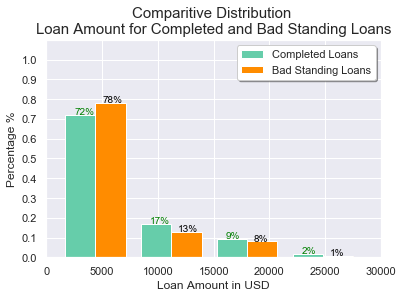

> The Loan Amount is consistent across both categorical distribtions. The main take away from the comparison is that in both cases, the dataset skews heavily favor smaller loans less than 15,000 USD to the larger loans. For Bad Standing Loans, 91% of loans are under 15,000 USD. Similarly 89% of all Completed Loans were under 15,000 USD.

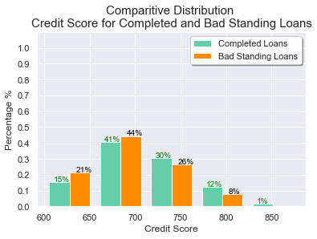

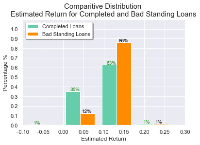

> Bad Standing Loans had a very small amount of loans whose estimated return fell from 0.0 to 0.05, with only 12%. 86% of the Bad Standing Loans had a return from 0.10 to .15. Completely Loans only had 63% percent that fell in this same bin. From this it can be derived that for most Bad Standing Loans, the rate of return was higher, likely related to the higher borrowering APR, in which case the lender was more economically incentivized to loan at a higher rate of return, but this was also more likely for the the lendee to end without ever being able to repay their loan.

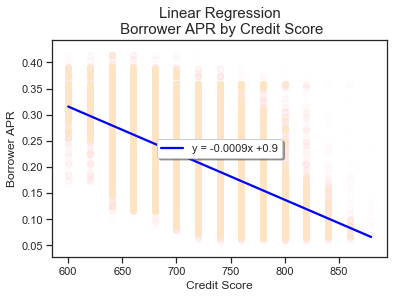

> The output displaying the Linear Regression of Borrower APR by Credit Score shows negative relationship between Credit Score and the Borrower APR. For every point that the Credit Score increases, the Borrower APR decreases by 0.0009 points.

```
''
```

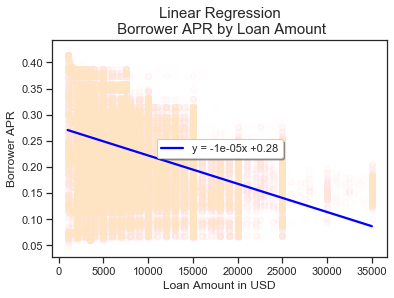

> The output displaying the Linear Regression of Borrower APR by Loan Amount shows negative relationship between Loan Amount and the Borrower APR. For every 1000 USD the Loan Amount increases, the Borrower APR decreases by 0.01 points.

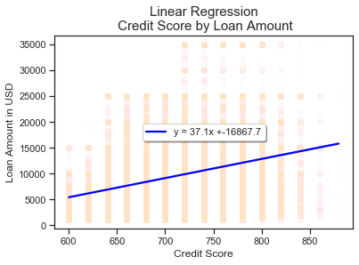

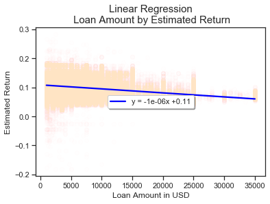

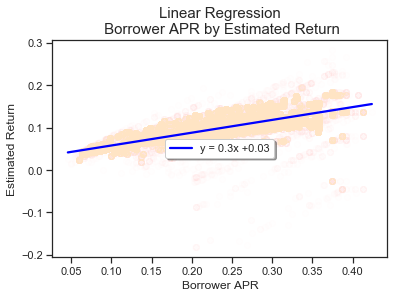

> The output displaying the Linear Regression of Borrower APR by Estimated Return shows a strong positive relationship between Borrower APR and the Estimated Return. For every 0.1 percent the Borrower APR increases, the Estimated Return Increases by 0.03 points.

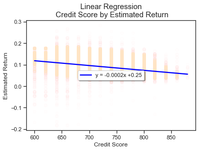

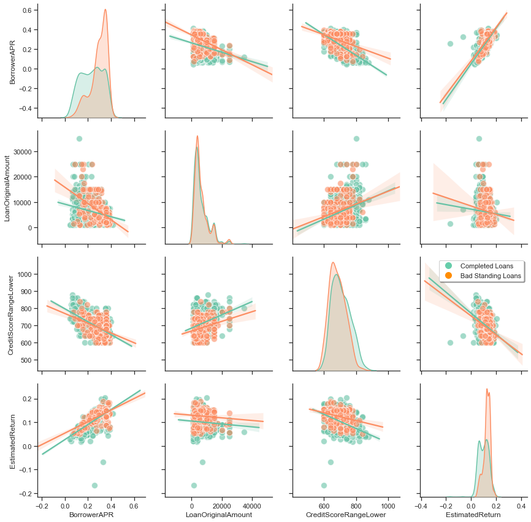

> The chart above displays the linear relationship as well as the distributions of the data as we have already saw in the last section. However in this output we can see the linear relationships and distribution of variables group by Loan Status. The linear regression of each variable shows the same positive and negative relationships, but some experience a higher degree of strenghth for Completed Loans vs Bad Standing Loans. For both Completed Loans and Bad Standing Loans, as the Borrower APR increased, so did the Estimated Return. This relatioship appears to be the strongest among the featured variables. Interesting note that as the Borrower APR increased for Completed Loans, the Estimated Return had a strong positive relationship then the loans that finished in Bad Standing. This could be a indicator that for many of the loans that were in Bad Standing, it is likely that the amount of risk associated was known and calculated in to the formula to determine the Estimated Return.

> Another interesting discovery was that the for the loans that were finished in Bad Standing, the relationship between Credit Score and Loan Amount had a much stronger positive relationship. From this, we can extrapolate that for the individuals of high Credit Scores who were unable to repay their loans, it was likely due to receiving a loan of high amount.

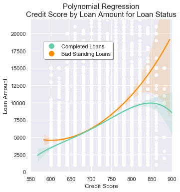

> As observed above and by this ouput, that for lendees who were unable who were unable to repay their loans, loans given to individuals of mid to low credit were less than 7,500 USD but as the Credit Score exceeds 750 the Loan Amounts become increasingly higher. This is uncharacteristic to the Completed Loans, were the loan amount range tops off near 10,000 USD for individuals of the highest Credit Score.

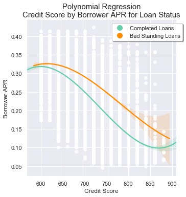

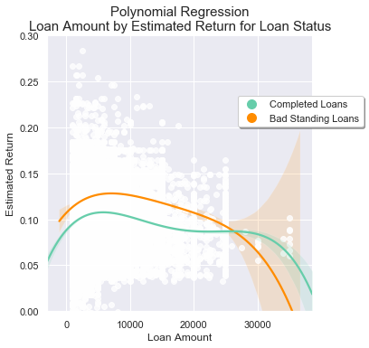

> The Estimated Return maximizes at a Loan Amount near 7500 USD and than decreases steadily for both Completed Loans and Bad Standing Loans. Again here we can see that for nearly all loan amounts the Estimated Return is higher for the Bad Standing Loans than the Completely Loans. This is further evidence that the Borrower APR was the strongest factor in Estimated Return. Once crossing 25,000 USD the Estimated Return falls off considerable for Bad Standing Loan. Below I will look into the the Loan Amount by Borrower APR to investigate this.

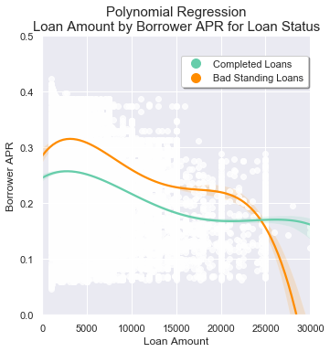

> As mentioned above, the Estimated Return fell off considerably after passing the 25,000 and we can see here that the reason for this was due to the rapid decrease in Borrower APR. For the loans that were unable to be repaid, it appears that the APR was low enough to incentivize them the higher amounts, and in turn putting them at a higher risk of never being able to repay.

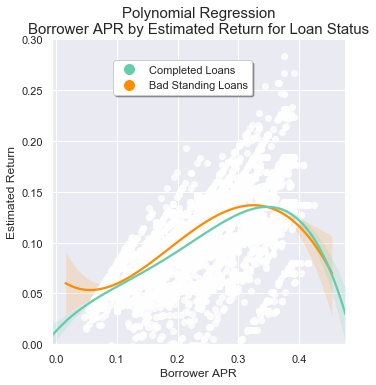

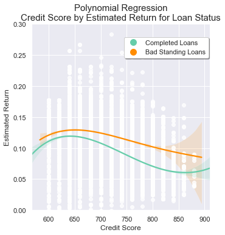